# VAR(p) model

Doynikov A

February 27, 2016

## Многомерные модели авторегрессии (VAR)

На практике нас чаще всего интересуют процессы многомерные, поведение которых в некотором смысле связано между собой. Итак пусть теперь $x_{t}$-векторный случайный процесс размерности $(n×1)$. Векторным процессом авторегрессии порядка $p$ (сокращенно VAR(p) ) будем называть процесс вида
$$x_{t}=с+\Phi_{1}x_{t-1}+...+\Phi_{p}x_{t-p}+\epsilon_{t}$$

где c- вектор (n×1) констант, $\Phi_{i}; i=1,...p$- матрицы размера (n×n) и $\epsilon_{t}$-многомерный (n×1)процесс белого шума

$$E\epsilon_{t}=0$$
$$E\epsilon_{t}\epsilon_{s}=\Omega$$
при $t=s$; 0 иначе, где $\Omega$- симметричная положительно определенная (n×n) матрица ковариаций.

Выпишем соотношение, например, для первого из компонент вектора $x_{t}$
$$x_{1,t} = c_1+\Phi_{1,1}^{(1)}x_{1,t-1}+\Phi_{1,2}^{(1)}x_{2,t-1}...+\Phi_{1,n}^{(1)}x_{n,t-1}+ \Phi_{1,1}^{(2)} x_{1,t-2}+\Phi_{1,2}^{(2)} x_{2,t-2}+...+\Phi_{1,n}^{(2)} x_{n,t-2} +...+$$
$$\Phi_{1,1}^{(p)} x_{1,t-p}+\Phi_{1,2}^{(p)}x_{2,t-p}...+\Phi_{1,n}^{(p)}x_{n,t-p}+\epsilon_{t,1}$$

Таким образом каждая из компонент процесса представляет собой одновременно как линейную регрессионную модель от других компонент процесса, но взятых с задержкой по времени и авторегрессионную модель от самой себя.

Используя векторный оператор задержки $Bx_{t}=x_{t-1}$ модель может быть записана в форме

$$[I_{n}-\Phi_1B-...-\Phi_{p}B^{p}]x_{t}=c+\epsilon_{t}$$

или

$$\Phi(B)x_{t}=c+\epsilon_{t}$$

где $\Phi(B)$- матрица размера (n×n) полиномов от оператора задержки, каждый элемент которой представляет собой скалярный полином от задержки

$$\Phi(B)=[\delta_{ij}-\Phi_{ij}B-...-\Phi_{ij}^{p}B^{p}]; i,j=1,...,n$$

где $\delta_{ij}=1$ при $i=j$, иначе 0

Процесс VAR(p) называют стационарным в широком смысле (или просто стационарным), если его первый и второй момент $Ex_{t}$ и $Ex_{t}x_{t-j}′$ соответсвенно не зависит от времени $t$.

Если процесс стационарен, то мы можем взять математическое ожидание от обеих частей и вычислить математическое ожидание процесса. Обозначим вектор математических ожиданий через $\mu=Ex_{t}$, тогда
$$\mu=с+\Phi₁\mu+...+\Phi_{p}\mu$$
Откуда
$$\mu=(I_{n}-\Phi_1-...-\Phi_{p})^{-1}c$$
Используя вектор математических ожиданий $\mu$, модель VAR(p) может быть эквивалентно переписана в терминах отклонений от среднего $\mu$.
$$x_{t}-\mu=\Phi_1(x_{t-1}-\mu)+...+\Phi_{p}(x_{t-p}-\mu)+\epsilon_{t}$$

Предложение. Многомерная модель VAR(p), так и одномерная модель AR(p) может быть переписана как многомерная модель VAR(1) Доказательство. Действительно, обозначим через $\xi_{t}$- многомерный размера (np×1)процесс вида
$$\begin{equation*}\xi_{t}=\left[ \begin{matrix}x_t-\mu\\ x_{t-1}-\mu\\
....\\x_{t-p}-\mu\end{matrix}\right] \end{equation*}$$
Пусть $F$ матрица размера (np×np)
$$\begin{equation*}F=\left[ \begin{matrix}\
\Phi_1&\Phi_2&\Phi_3&...&\Phi_p\\
I_n&0&0&...&0\\
0&I_n&0&...&0\\
...\\
0&0&...&I_n&0&\\
\end{matrix}\right] \end{equation*}$$
и через $ν_{t}$- (np×1)-й процесс
$$\begin{equation*}v_{t}=\left[ \begin{matrix}\epsilon_t\\0\\...\\0\end{matrix}\right] \end{equation*}$$
Тогда многомерный VAR(p) процесс может быть эквивалентно переписан, как VAR(1) процесс вида
$$\xi_{t}=F\xi_{t-1}+ν_{t}$$
Доказанный факт чаще всего используется при доказательстве различных утверждений относительно процесса VAR(p).

### Условия стационарности процесса VAR(p)

Для процесса VAR(1) $\xi_{t}$ , введенного выше справедливо следующее выражение
$$\xi_{t+s}=ν_{t+s}+Fν_{t+s-1}+F^2ν_{t+s-2}+...+F^{s-1}ν_{t+1}+F^{s}\xi_{t}$$

Для того, чтобы процесс был стационарным влияние шума $\epsilon_{t}$ в конце концов должно исчезнуть. Оказывается, что если все собственные значения матрицы $F$ лежат внутри единичного круга, то процесс $\xi_{t}$ будет стационарным в широком смысле. Без доказательства примем на веру следующее утверждение Теорема. Все $\lambda$- собственные значения матрицы $F$, удовлетворяют уравнению
$$|I_{n}\lambda^{p}-\Phi_1\lambda^{p-1}-\Phi_2\lambda^{p-2}...-\Phi_{p}|=0$$
Следовательно, процесс VAR(p) является стационарным тогда и только тогда, когда все собственные значения матрицы F по модулю меньше единицы $|\lambda|<1$, что в свою очередь эквивалентно тому, все корни $z$ уравнения
$$|I_{n}-\Phi_1z-\Phi_2z²...-\Phi_{p}z^{p}|=0$$
лежат вне единичного круга. Доказательство этого утверждения можно найти в J.Hamilton. Time Series Analysis p.285.

### Автоковариационная функция векторного процесса

Для стационарного векторного процесса $x_{t}$ размера (n×1) $k$-ой автоковариацией назовем матрицу (n×n)
$$\Gamma_{k}=E[(x_{t}-\mu)(x_{t-k}-\mu)′]$$
Вспомним, что для одномерных процессов автоковариационная функция является четной функцией $c_{k}=c_{-k}$ , для векторного процесса это не верно.
$$\Gamma_{k}\ne\Gamma_{-k}$$
Однако, нетрудно убедиться, что
$$\Gamma_{k}′=\Gamma_{-k}$$

Действительно. Для стационарного процесса будет справедливо
$$\Gamma_{k}=E[(x_{t+k}-\mu)(x_{(t+k)-k}-\mu)′]=E[(x_{t+k}-\mu)(x_{t}-\mu)′]$$
Транспонируем
$$\Gamma_{k}′=E[(x_{t}-\mu)'(x_{t+k}-\mu)]=\Gamma_{-k}$$
В языке R соответствующая библиотека для работы с многомерными авторегрессионными моделями называется mAr Cмоделируем VAR(2) процесс размерности 3

Сначала зададим модель вектор констант $c$ и матрицы $\Phi_1,\Phi_2$ и ковариационную матрицу $\Omega$

```r
library(mAr)
w <- c(1,4,8)
Phi1 <- c(0.1,-0.2,-0.3)
Phi1 <- rbind(Phi1,c(0.1,0.-0.2,0.3))
Phi1 <- rbind(Phi1,c(0.2,0.2,0.2))
Phi1
```

```
##      [,1] [,2] [,3]
## Phi1  0.1 -0.2 -0.3
##       0.1 -0.2  0.3
##       0.2  0.2  0.2
```

```r
Phi2 <- c(0.1,0.1,0.1)
Phi2 <- rbind(Phi2,c(0.15,0.1,0.15))
Phi2 <- rbind(Phi2,c(0.1,0.1,0.1))
Phi2
```

```
##      [,1] [,2] [,3]
## Phi2 0.10  0.1 0.10
##      0.15  0.1 0.15
##      0.10  0.1 0.10
```

```r
Phi <- cbind(Phi1,Phi2)
Phi
```

```
##      [,1] [,2] [,3] [,4] [,5] [,6]
## Phi1  0.1 -0.2 -0.3 0.10  0.1 0.10
##       0.1 -0.2  0.3 0.15  0.1 0.15
##       0.2  0.2  0.2 0.10  0.1 0.10
```

```r
Omega <- diag(4,3,3)
Omega
```

```
##      [,1] [,2] [,3]
## [1,]    4    0    0
## [2,]    0    4    0
## [3,]    0    0    4
```

Cформируем из матриц $\Phi_1,\Phi_2$ матрицу $F$ для того, чтобы проверить стационарность модели

```r
I <- diag(1,3,3)
Zero <- diag(0,3,3)
IZ <- cbind(I,Zero)
F <- rbind(Phi,IZ)
F
```

```
##      [,1] [,2] [,3] [,4] [,5] [,6]
## Phi1  0.1 -0.2 -0.3 0.10  0.1 0.10
##       0.1 -0.2  0.3 0.15  0.1 0.15
##       0.2  0.2  0.2 0.10  0.1 0.10
##       1.0  0.0  0.0 0.00  0.0 0.00
##       0.0  1.0  0.0 0.00  0.0 0.00
##       0.0  0.0  1.0 0.00  0.0 0.00
```

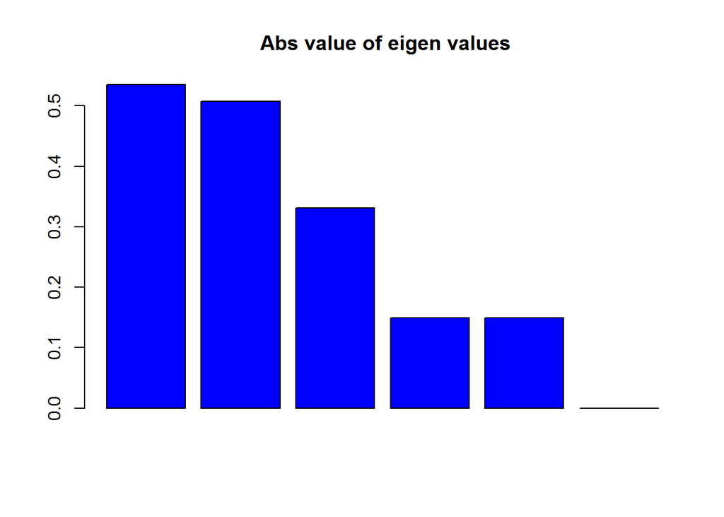

```r
eval <- eigen(F,only.values= TRUE)
modev <- Mod(eval$values)
barplot(modev,col = "blue",main = " Abs value of eigen values")
abline(h=1,col = "black")
```

Все собственные значения по модулю <1, следовательно ряд стационарен Моделируем и смотрим результат

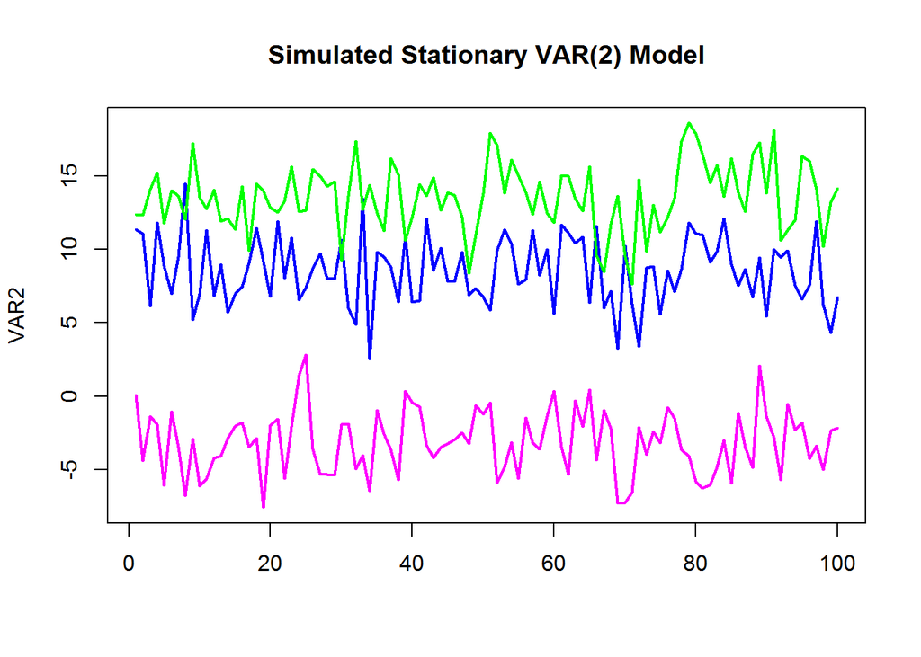

```r
VAR2 <- mAr.sim(w, Phi, Omega, 100)
matplot(VAR2,type="l",lty = 1, col=c("magenta","blue","green"),lwd=2,main = "Simulated Stationary VAR(2) Model")
```

Оценим по рядам параметры AR(2) и сравним с теми, что были заданы при моделировании

```r
model <- mAr.est(VAR2,2)
model$wHat
```

```
## [1] -1.116600  2.557999  8.720722
```

```r
model$AHat
```

```
##             [,1]       [,2]       [,3]        [,4]        [,5]        [,6]
## [1,]  0.22143442 -0.1777740 -0.3465564 0.005709915  0.24865367  0.20367967
## [2,] -0.01364572 -0.2976817  0.3685724 0.103362631 -0.07264549  0.32268100
## [3,]  0.08201659  0.1588554  0.2282995 0.306759320  0.25015629 -0.03776488
```

```r
model$CHat
```

```
##            [,1]       [,2]       [,3]
## [1,]  3.7681145 -0.3106520 -0.2368793
## [2,] -0.3106520  3.9770243 -0.4460738
## [3,] -0.2368793 -0.4460738  4.4189185
```

К сожалению метод не дает стандартных ошибок оценок и р-значений проверок гипотез о равенстве нулю параметров модели.

Другой метод оценки находится в библитетеке vars. Здесь уже есть выдача с проверкой гипотез о значимости оценок

```r
library(vars)
varsimest <− VAR( VAR2 , p = 2 ,season = NULL, exogen = NULL)
summary(varsimest)
```

```
##
## VAR Estimation Results:
## =========================
## Endogenous variables: X1, X2, X3
## Deterministic variables: const
## Sample size: 98
## Log Likelihood: -610.635
## Roots of the characteristic polynomial:
## 0.6905 0.6121 0.5376 0.5376 0.5348 0.5348
## Call:
## VAR(y = VAR2, p = 2, exogen = NULL)
##
##
## Estimation results for equation X1:
## ===================================
## X1 = X1.l1 + X2.l1 + X3.l1 + X1.l2 + X2.l2 + X3.l2 + const
##
##       Estimate Std. Error t value Pr(>|t|)
## X1.l1  0.22143    0.09850   2.248 0.026993 *
## X2.l1 -0.17777    0.09598  -1.852 0.067224 .
## X3.l1 -0.34656    0.09014  -3.845 0.000223 ***
## X1.l2  0.00571    0.09237   0.062 0.950844
## X2.l2  0.24865    0.08927   2.785 0.006507 **
## X3.l2  0.20368    0.10291   1.979 0.050807 .
## const -1.11660    1.72216  -0.648 0.518377
## ---
## Signif. codes:  0 '***' 0.001 '**' 0.01 '*' 0.05 '.' 0.1 ' ' 1
##
##
## Residual standard error: 1.941 on 91 degrees of freedom
## Multiple R-Squared: 0.238,   Adjusted R-squared: 0.1877
## F-statistic: 4.736 on 6 and 91 DF,  p-value: 0.0003059
##
##
## Estimation results for equation X2:
## ===================================
## X2 = X1.l1 + X2.l1 + X3.l1 + X1.l2 + X2.l2 + X3.l2 + const
##
##       Estimate Std. Error t value Pr(>|t|)
## X1.l1 -0.01365    0.10120  -0.135 0.893034
```

[output cut: 33 more lines]

```
## F-statistic: 3.871 on 6 and 91 DF,  p-value: 0.001738
##
##
##
## Covariance matrix of residuals:
##         X1      X2      X3
## X1  3.7681 -0.3107 -0.2369
## X2 -0.3107  3.9770 -0.4461
## X3 -0.2369 -0.4461  4.4189
##
## Correlation matrix of residuals:
##          X1       X2       X3
## X1  1.00000 -0.08025 -0.05805
## X2 -0.08025  1.00000 -0.10641
## X3 -0.05805 -0.10641  1.00000
```

В этой библиотеке также присутствут очень удобный метод VARselect, который позволяет оценить порядок модели $p$, когда он неизвестен Это делается с помощью 4 информационных критериев, среди которых и известный нам уже критерий Акаике, который в многомерном случае выглядит следубщим образом
$$AIC(n) = \ln \det(\tilde{Σ}_u(n)) + \frac{2}{T}n K^2 \quad$$
где
$$\tilde{Σ}_u (n) = T^{-1} ∑_{t=1}^T \hat{u}_t \hat{u}_t'$$
где $u_t$ вектора остатков.

```r
nfocrit <− VARselect(VAR2, lag.max = 5, type="const")
nfocrit
```

```
## $selection
## AIC(n)  HQ(n)  SC(n) FPE(n)
##      2      2      1      2
##
## $criteria
##                 1         2         3          4          5
## AIC(n)   4.618066  4.400560  4.485236   4.603217   4.722503
## HQ(n)    4.748419  4.628677  4.811118   5.026863   5.243913
## SC(n)    4.940661  4.965101  5.291724   5.651650   6.012883
## FPE(n) 101.313122 81.561913 88.906428 100.323514 113.547778
```

Про другие критерии можно прочитать в help по этому методу. Прогнозирование также, как и в ARMA модели это условное математическое ожидание, которое в данном случае при прогнозе на один шаг времени вперед будет

$$E[x(t+1)|x_1,...x_t] = с+\Phi_{1}x_{t}+...+\Phi_{p}x_{t-p+1}$$
прогноз на $l$ шагов вперед вычисляется последовательно через прогнозы на $l-1,...1$ шагов. Соответствующий метод показан ниже

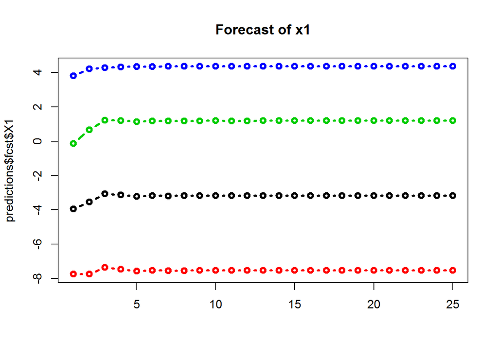

```r
predictions <− predict ( varsimest , n.ahead = 25 ,ci = 0.95)
matplot(predictions$fcst$X1,type = "b",pch = 21,lty = 1,lwd = 3,main = "Forecast of x1")
```

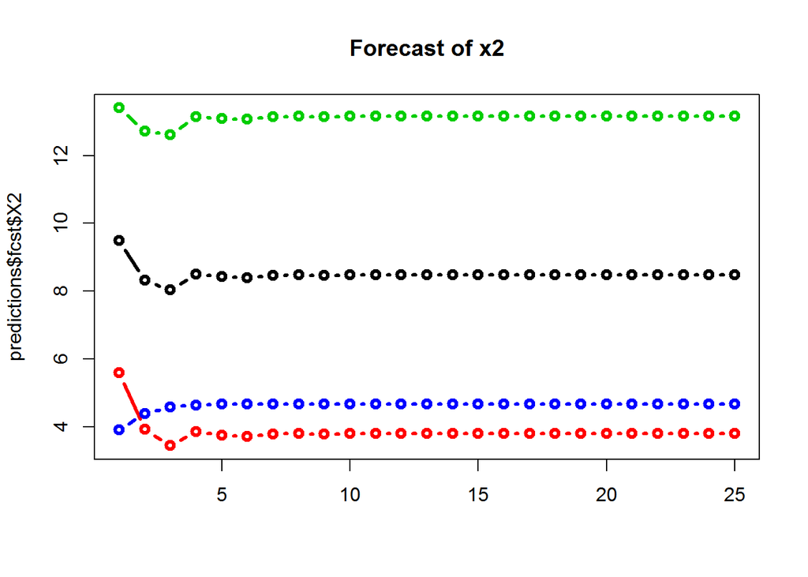

```r
matplot(predictions$fcst$X2,type = "b",pch = 21,lty = 1,lwd = 3,main = "Forecast of x2")
```

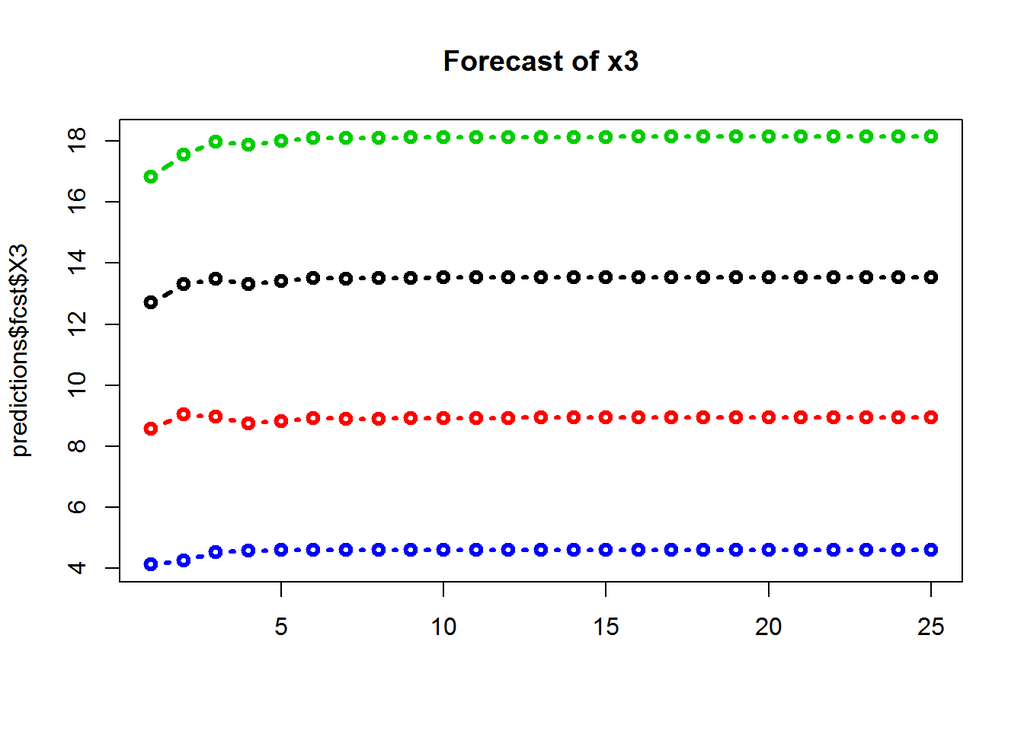

```r
matplot(predictions$fcst$X3,type = "b",pch = 21,lty = 1,lwd = 3,main = "Forecast of x3")
```

# Литература

- Кендал М.Дж. Стюарт А. (1976) Многомерный статистический анализ и временные ряды, М:Наука
- Hamilton J.D. (1994): Time Series Analysis. Princeton University Press.
- Lütkepohl, H. (2006), New Introduction to Multiple Time Series Analysis, Springer, New York